# Practical 3: Linear models

BIOM4025 - Statistical Modelling

Erik Postma / Centre for Ecology and Conservation / University of Exeter

Weeks 5 and 6: 21 October - 1 November 2024

# Introduction

Telomeres are repetitive DNA segments that cap the ends of chromosomes. Telomeres shorten with each cell division and are sensitive to oxidative damage, and short telomeres have been shown to trigger cellular senescence and may be related to lifespan. Telomere length (TL) is therefore considered a promising biomarker of physiological state and of past environmental experiences.

Over the past few years, there has been a lot of interest in using variation in telomere length to understand the drivers of life-history variation in a range of species, including wild birds and mammals. In this practical, we will use data on telomere length in roe deer, collected by Wilbourn and colleagues (2017).

> **PREPARATION**  
> To familiarise yourself with the topic and study system, read this paper: Wilbourn *et al.*, 2017. Age-dependent associations between telomere length and environmental conditions in roe deer. *Biology Letters* **13**: 20170434. http://dx.doi.org/10.1098/rsbl.2017.0434. A PDF of the paper can also be found on the [ELE page](https://ele.exeter.ac.uk/pluginfile.php/4275270/mod_folder/content/0/Wilbourn%20et%20al%202017.pdf?forcedownload=1).  
> Furthermore, as Section 2 is largely a repetition from the last two practicals, so if you are short on time I would recommend you focus on Sections 3-5.

Many journals, including *Biology Letters*, have made it compulsory to make the data on which an article is based publicly available. This is good news for us, as it allows us to reanalyse their data and compare our results to those presented in the paper. The data can be downloaded [here](https://figshare.com/collections/Supplementary_material_from_Age-dependent_associations_between_telomere_length_and_environmental_conditions_in_roe_deer_/3879718) or from the [ELE page](https://ele.exeter.ac.uk/course/view.php?id=18633#section-8).

> **NOTE**  
> Only have a look at the **HARD EXERCISES** once you have finished with all the rest, and don’t worry if you can’t solve all of them: They are pretty hard!

# Getting started

## Importing the data

Copy the data file into a folder on your computer and have a look at it using *Excel* or the text editor of your choice. Do the column names contain any spaces? Are they short but informative? Do any of the columns contain missing values?

Once you are happy with what your data file looks like, import it into `R`. You will have to tell `R` where to find the file using `setwd()` and then use `read.table()` to read it into `R`:

```r
setwd("/This/Is/Path/To/My/Working/Directory")
tl.data <- read.table("rsbl20170434_si_002.csv", header=TRUE, sep = ",",
                      stringsAsFactors = FALSE)
```

Note that the file was a `comma-seperated (.csv)` file, which means that columns are separated by a `,`. This is why we specified `sep=","`. Alternatively, we could also have used `read.csv()`, which is similar to `read.table()`, but it expects a `.csv.` file by default. Also, note that I specified `stringsAsFactors = FALSE`. This prevents `R` from converting character variables to factors. Although in this case it won’t really matter much, often working with characters is easier than working with factors, especially if we want to manipulate their content (*e.g.* using `substr()`).

## Checking the data

To see whether our data has imported correctly, we use `names()`, `head()`, `tail()` and `summary()`:

```r
names(tl.data)
```

```
[1] "Population" "Sex"        "Age"        "BodyMass"   "RTL"
```

```r
head(tl.data)
```

```
  Population Sex Age BodyMass       RTL
1         CH   F   1    11.75 0.9686877
2         CH   F   1    12.25 1.1488749
3         CH   F   1    11.75 0.8728015
4         CH   F   1    11.65 1.1779235
5         CH   F   1     8.70 0.8174618
6         CH   F   1    12.75 0.9942669
```

```r
tail(tl.data)
```

```
    Population Sex Age BodyMass      RTL
134         TF   F   9     25.8 1.595319
135         TF   M   9     24.6 1.249564
136         TF   M   9     27.0 1.108427
137         TF   F  11     23.4 1.243616
138         TF   M  12     23.8 1.202837
139         TF   F  13     24.5 1.145971
```

```r
summary(tl.data)
```

```
  Population            Sex                 Age           BodyMass
 Length:139         Length:139         Min.   : 1.00   Min.   : 8.70
 Class :character   Class :character   1st Qu.: 1.00   1st Qu.:16.45
 Mode  :character   Mode  :character   Median : 3.00   Median :20.10
                                       Mean   : 4.05   Mean   :19.89
                                       3rd Qu.: 6.00   3rd Qu.:23.40
                                       Max.   :13.00   Max.   :29.00
      RTL
 Min.   :0.7058
 1st Qu.:0.9426
 Median :1.0609
 Mean   :1.0696
 3rd Qu.:1.2075
 Max.   :1.5953
```

## Sample sizes

We have data on relative telomere length for roe deer from different populations. To find out the sample size per population, we can use `table()`:

```r
table(tl.data$Population)
```

```
CH TF
66 73
```

We can also make a table of the number of males and females per population:

```r
table(tl.data$Sex, tl.data$Population)
```

```
    CH TF
  F 36 34
  M 30 39
```

> **EXERCISE 3.1**  
> How many males and females do we have per age class? And how would you get the number of males and females per age class for the two populations separately?

## Descriptive statistics

The `aggregate()` function is a useful tool to obtain some descriptive statistics. For example, to obtain the mean `BodyMass` per population, we use:

```r
aggregate(tl.data$BodyMass, by=list(tl.data$Population), mean)
```

```
  Group.1        x
1      CH 18.60303
2      TF 21.05479
```

If we would like to use the output from `aggregate()` for further calculations or to create a plot, we have to store the output. For example, to create an object that contains the mean `BodyMass` for each age class, we run:

```r
mean.bm.age <- aggregate(tl.data$BodyMass, by=list(tl.data$Age), mean)
mean.bm.age
```

```
   Group.1        x
1        1 15.00532
2        2 21.02143
3        3 21.51429
4        4 22.63500
5        5 24.01111
6        6 23.17273
7        7 23.54286
8        8 22.12727
9        9 24.60000
10      10 19.97500
11      11 22.20000
12      12 23.80000
13      13 22.02500
```

Unfortunately, the column names of `mean.bm.age` are not very informative. This can however easily be fixed using the `colnames()` function:

```r
colnames(mean.bm.age) <- c("Age", "MeanBodyMass")
head(mean.bm.age)
```

```
  Age MeanBodyMass
1   1     15.00532
2   2     21.02143
3   3     21.51429
4   4     22.63500
5   5     24.01111
6   6     23.17273
```

We can use `aggregate()` with other functions as well, such as `length()` or `sd()`. For example, we can calculate the standard deviation of body mass per age group as follows:

```r
sd.bm.age <- aggregate(tl.data$BodyMass, by=list(tl.data$Age), sd)
colnames(sd.bm.age) <- c("Age", "SdBodyMass")
head(sd.bm.age)
```

```
  Age SdBodyMass
1   1   2.869257
2   2   3.207397
3   3   2.669693
4   4   3.408164
5   5   2.690351
6   6   3.193616
```

We can now combine `mean.bm.age` and `sd.bm.age` into a single data frame. In this case, as both data frames are the same size and in the same order, we can simply take `sd.bm.age$SdBodyMass` and add it to `mean.bm.age`:

```r
mean.bm.age$SdBodyMass <- sd.bm.age$SdBodyMass
head(mean.bm.age)
```

```
  Age MeanBodyMass SdBodyMass
1   1     15.00532   2.869257
2   2     21.02143   3.207397
3   3     21.51429   2.669693
4   4     22.63500   3.408164
5   5     24.01111   2.690351
6   6     23.17273   3.193616
```

## Missing data

Have another look at the output of `summary()`. You will see that in this case we are in the fortunate situation that we have no missing data (*i.e.* our data set contains no `NA`’s). This is not always the case, and this can cause significant problems.

For example, let’s create a new `BodyMass` column in `tl.data` (called `BodyMass2`) and at random introduce 5 `NA`’s:

```r
tl.data$BodyMass2 <- tl.data$BodyMass
tl.data$BodyMass2[sample(nrow(tl.data), 5)] <- NA
summary(tl.data$BodyMass2)
```

```
   Min. 1st Qu.  Median    Mean 3rd Qu.    Max.    NA's
   8.70   16.80   20.30   20.07   23.55   29.00       5
```

> **EXERCISE 3.2 (HARD)**  
> Above I used the `sample()` function. Have a look at `?sample` and explore how it works. Now use `sample()` to create a new variable called `RandomAge` and calculate the mean body mass for each level of `RandomAge`. Compare these to the mean body mass per age class calculated above. What does this difference suggest with respect to the effect of age on body mass?

If we try to calculate the mean of `BodyMass2`, we get the following:

```r
mean(tl.data$BodyMass2)
```

```
[1] NA
```

`R` is very strict when it comes to `NA`s: As soon as it encounters an `NA`, it will refuse to calculate a mean. To nevertheless be able to calculate a mean, we will first need to remove any `NA`’s using `is.na()`:

```r
mean(tl.data$BodyMass2[is.na(tl.data$BodyMass2)==FALSE])
```

```
[1] 20.0709
```

Alternatively, we can use `na.omit()`, which removes all records that contain missing values:

```r
mean(na.omit(tl.data$BodyMass2))
```

```
[1] 20.0709
```

However, be careful when using `na.omit()`: When applied to a complete data frame (and not a single column as we did above), it will remove all records with `NA`s, also if the `NA`’s are located in a variable that is not relevant to your analysis.

Finally, `mean()` very conveniently also has a built-in option to remove `NA`s:

```r
mean(tl.data$BodyMass2, na.rm = TRUE)
```

```
[1] 20.0709
```

Also,when we try to subset on the basis of variable that contains `NA`’s, `R` will retain the missing values:

```r
tl.data$BodyMass2[tl.data$BodyMass2 > 26]
```

```
 [1]   NA   NA   NA   NA   NA 27.1 28.8 27.1 29.0 26.5 26.5 26.7 27.4 27.0
```

```r
length(tl.data$BodyMass2[tl.data$BodyMass2 > 26])
```

```
[1] 14
```

This means that if we want the number of individuals that is heavier than 26 kg, we need to explicitly remove any `NA`’s:

```r
tl.data$BodyMass2[is.na(tl.data$BodyMass2)==FALSE & tl.data$BodyMass2 > 26]
```

```
[1] 27.1 28.8 27.1 29.0 26.5 26.5 26.7 27.4 27.0
```

```r
length(tl.data$BodyMass2[is.na(tl.data$BodyMass2)==FALSE & tl.data$BodyMass2 > 26])
```

```
[1] 9
```

Alternatively, we can again use `na.omit()`:

```r
length(tl.data$BodyMass2[na.omit(tl.data$BodyMass2) > 26])
```

```
[1] 9
```

# Does telomere length decline with age?

## Linear regression

To test if telomeres get shorter with age, we need to do a regression of `RTL` against `Age` using `lm()`, but before we do this, let’s look at the distribution of both variables by plotting two histograms:

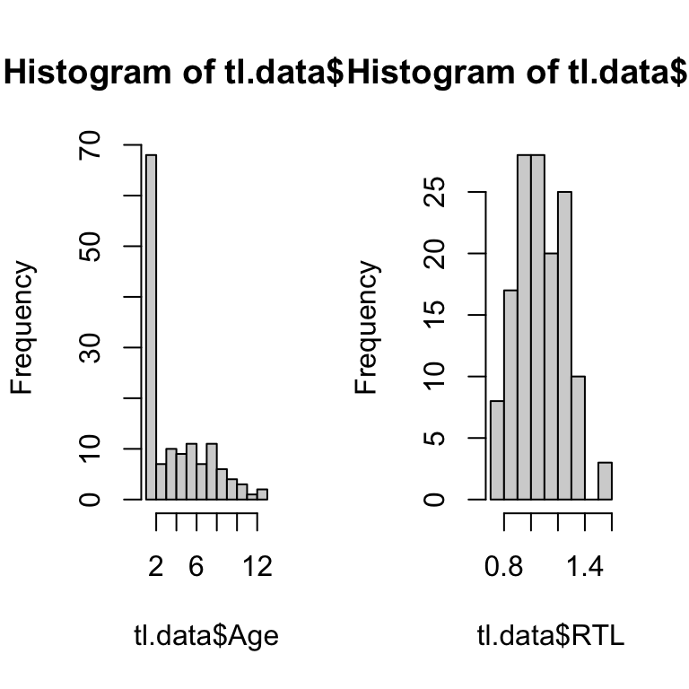

```r
par(mfrow=c(1,2))
hist(tl.data$Age)
hist(tl.data$RTL)
```

> **EXERCISE 3.3**  
> What do you conclude from these histograms? Are they a problem for your linear regression?

To specify our linear model, we first specify the dependent variable (`RTL`), followed by a `~` and the predictor variable `Age`:

```r
lm(RTL ~ Age, data = tl.data)
```

```
Call:
lm(formula = RTL ~ Age, data = tl.data)

Coefficients:
(Intercept)          Age
  1.070e+00   -8.134e-05
```

Although this does provide us with an estimate of the slope and the intercept, it doesn’t provide any more information. However, we can use the `summary()` function (the same one that we use to get more information about our data frame!):

```r
summary(lm(RTL ~ Age, data = tl.data))
```

```
Call:
lm(formula = RTL ~ Age, data = tl.data)

Residuals:
     Min       1Q   Median       3Q      Max
-0.36362 -0.12718 -0.00843  0.13783  0.52616

Coefficients:
              Estimate Std. Error t value Pr(>|t|)
(Intercept)  1.070e+00  2.423e-02  44.159   <2e-16 ***
Age         -8.134e-05  4.663e-03  -0.017    0.986
---
Signif. codes:  0 '***' 0.001 '**' 0.01 '*' 0.05 '.' 0.1 ' ' 1

Residual standard error: 0.1789 on 137 degrees of freedom
Multiple R-squared:  2.221e-06, Adjusted R-squared:  -0.007297
F-statistic: 0.0003043 on 1 and 137 DF,  p-value: 0.9861
```

Instead of using a t-test to test if the slope is significantly different from zero, we could also do an ANOVA:

```r
anova(lm(RTL ~ Age, data = tl.data))
```

```
Analysis of Variance Table

Response: RTL
           Df Sum Sq  Mean Sq F value Pr(>F)
Age         1 0.0000 0.000010   3e-04 0.9861
Residuals 137 4.3863 0.032017
```

> **EXERCISE 3.4**  
> Compare the output obtained using `summary()` and `anova()`. What are the similarities, and what are the differences?

Based on these results, we write in the Results section of our paper something like this: There is little evidence for a relationship between age and relative telomere length (b ± SE: -8.13 $\times$ 10<sup>-5</sup> ± 4.66 $\times$ 10<sup>-3</sup>, $F_{1,137}$=0.0003, P = 0.986).

## Model diagnostics

To check whether any of the assumptions of linear regression are violated, we first store the output of the model and then use `plot()` to create four diagnostic plots:

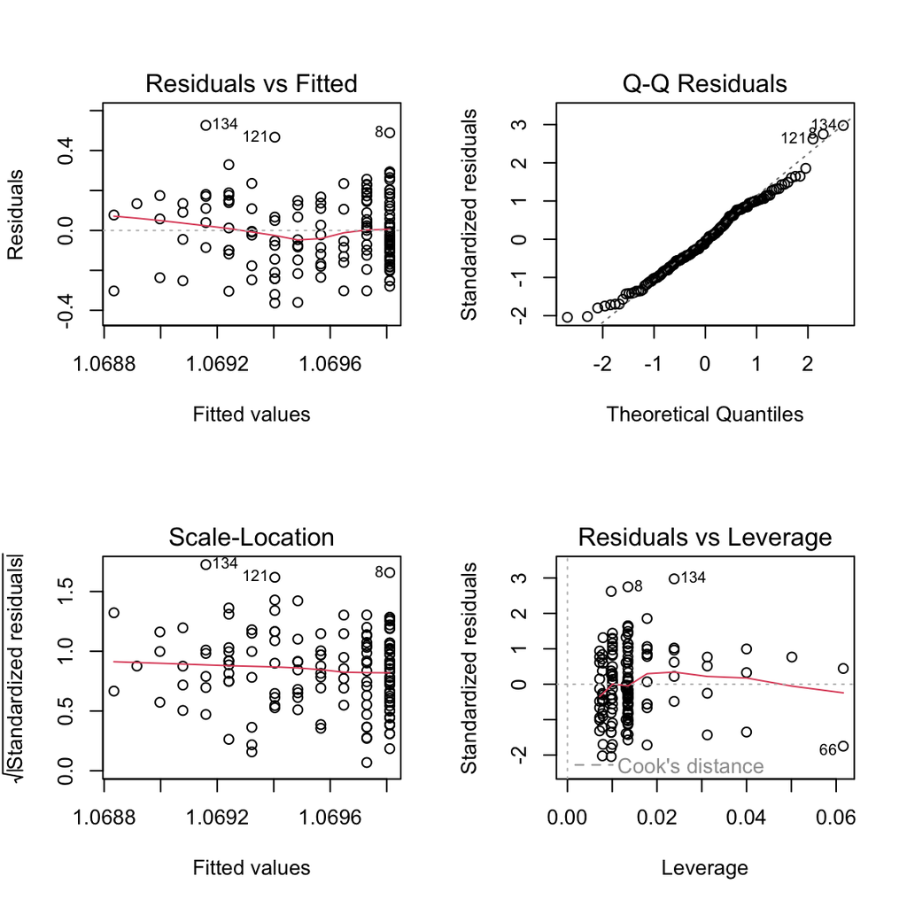

```r
m.rtl.age <- lm(RTL ~ Age, data = tl.data)
par(mfrow=c(2,2))
plot(m.rtl.age)
```

> **EXERCISE 3.5**  
> What conclusion do you draw from these diagnostic plots?

The first of the four diagnostic plots shows the residuals of the model plotted against the fitted values. We can extract these values from our model ourself, using `resid()` and `predict()`:

```r
resid.m.rtl.age <- resid(m.rtl.age)
predict.m.rtl.age <- predict(m.rtl.age)
```

We can then use these to plot a histogram of the residuals, plot the residuals against the fitted values, and create a quantile-quantile plot of the residuals:

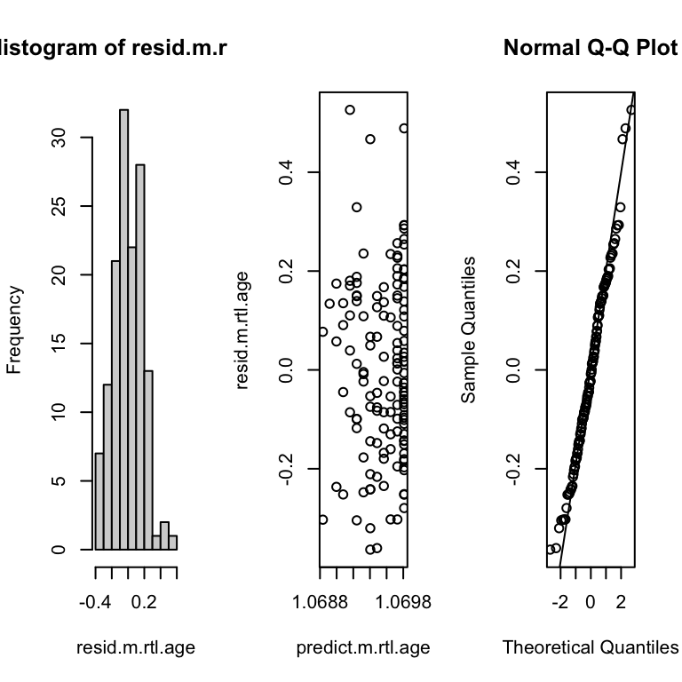

```r
par(mfrow=c(1,3))
hist(resid.m.rtl.age)
plot(resid.m.rtl.age ~ predict.m.rtl.age)
qqnorm(resid.m.rtl.age)
qqline(resid.m.rtl.age)
```

## Plotting a regression

In a final step, we would like to visualise the (apparent lack of a) relationship between telomere length and age using a scatter plot of `RTL` against `Age`:

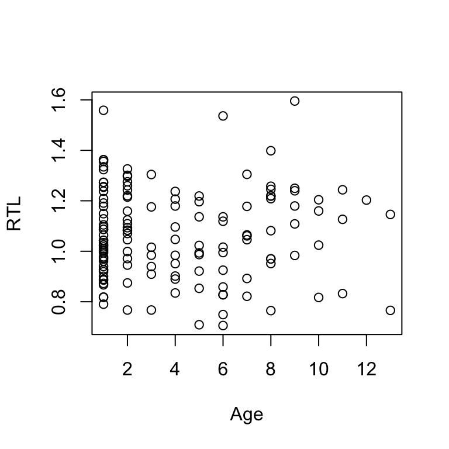

```r
par(mfrow=c(1,1))
plot(RTL ~ Age, data=tl.data)
```

Although it does the job, we can make this plot look a bit nicer. `?par` provides an overview of the many options you have to customise your plot. For example, we can use `cex.lab` to make our labels a bit larger, `col` to specify the colour of our symbols, `font.lab` to create **bold** axes labels and `pch` to change the symbols. Furthermore, we can use `xlab` and `ylab` to change our axis labels, and `xlim` and `ylim` to change the range of our axes.

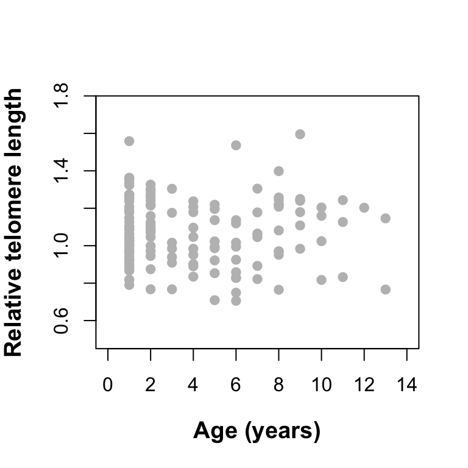

```r
plot(RTL ~ Age, data=tl.data, cex.lab=1.2, col="grey", font.lab=2, pch=19,
     xlim=c(0,14), ylim=c(0.5, 1.75), xlab="Age (years)", ylab="Relative telomere length")
```

Although the relationship is not significant, it would still be nice to include the regression line. We can do this using `abline()`, which provides a range of options to add straight lines to plots (see `?abline`). The easiest way of plotting a regression line is by simply specifying the model within `abline()`:

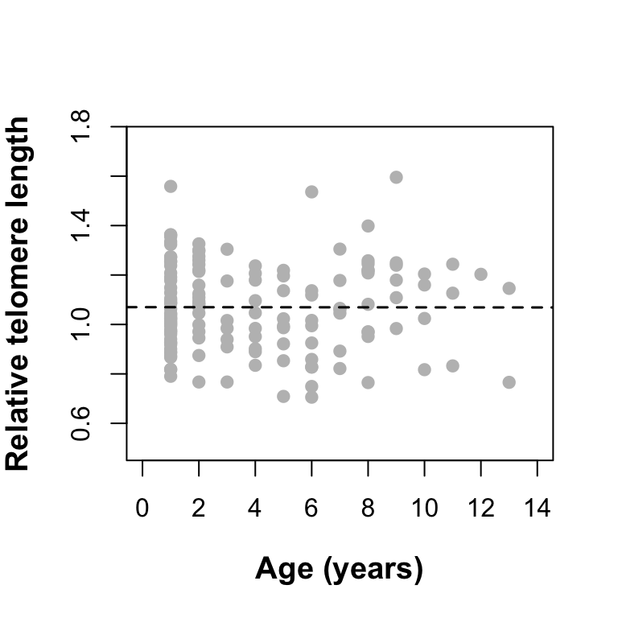

```r
plot(RTL ~ Age, data=tl.data, cex.lab=1.2, col="grey", font.lab=2, pch=19,
     xlim=c(0,14), ylim=c(0.5, 1.75), xlab="Age (years)", ylab="Relative telomere length")
abline(m.rtl.age, lty=2, lwd=1.5)
```

To make it clear that the relationship is not significant, we included `lty=2` to plot a dashed rather than a solid line, and we used `lwd=1.5` to make it a bit thicker.

# Variation in body mass

## The effect of age on body mass

Just as we did for `RTL`, we can test whether `BodyMass` changes with age by performing a regression:

```r
m.bm.age <- lm(BodyMass ~ Age, data=tl.data)
summary(m.bm.age)
```

```
Call:
lm(formula = BodyMass ~ Age, data = tl.data)

Residuals:
   Min     1Q Median     3Q    Max
-8.755 -2.250 -0.355  2.197  8.950

Coefficients:
            Estimate Std. Error t value Pr(>|t|)
(Intercept) 16.65656    0.50520  32.971  < 2e-16 ***
Age          0.79847    0.09722   8.213 1.44e-13 ***
---
Signif. codes:  0 '***' 0.001 '**' 0.01 '*' 0.05 '.' 0.1 ' ' 1

Residual standard error: 3.731 on 137 degrees of freedom
Multiple R-squared:  0.3299,    Adjusted R-squared:  0.325
F-statistic: 67.45 on 1 and 137 DF,  p-value: 1.439e-13
```

> **EXERCISE 3.6**  
> Plot the residuals against the fitted values. What does this suggest?

It is unlikely that individuals continue to grow after a certain age, and hence we would expect a curvilinear effect of age on body mass. We can test this by including age as an additional quadratic term in our model:

```r
m.bm.age.2 <- lm(BodyMass ~ Age + I(Age^2), data=tl.data)
summary(m.bm.age.2)
```

```
Call:
lm(formula = BodyMass ~ Age + I(Age^2), data = tl.data)

Residuals:
    Min      1Q  Median      3Q     Max
-7.4134 -2.1715 -0.1297  1.8307  8.6687

Coefficients:
            Estimate Std. Error t value Pr(>|t|)
(Intercept) 13.40443    0.61741  21.711  < 2e-16 ***
Age          2.90439    0.29898   9.714  < 2e-16 ***
I(Age^2)    -0.19547    0.02667  -7.329 1.86e-11 ***
---
Signif. codes:  0 '***' 0.001 '**' 0.01 '*' 0.05 '.' 0.1 ' ' 1

Residual standard error: 3.171 on 136 degrees of freedom
Multiple R-squared:  0.5196,    Adjusted R-squared:  0.5126
F-statistic: 73.56 on 2 and 136 DF,  p-value: < 2.2e-16
```

Note that to fit `Age^2`, we need to write `I(Age^2)`.

We should never rely solely on the output our linear model, but always visualise the relationship as well:

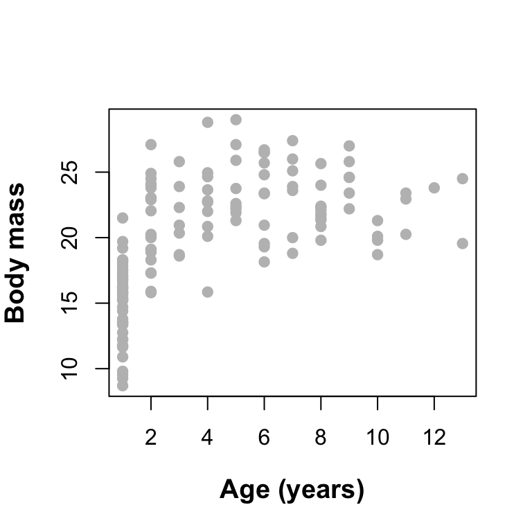

```r
plot(BodyMass ~ Age, data=tl.data, cex.lab=1.2, col="grey", font.lab=2, pch=19,
     xlab="Age (years)", ylab="Body mass")
```

This makes it immediately clear that the relationship between `Age` and `BodyMass` is not described very well by a straight line.

Unfortunately `abline()` does not allow us to plot polynomials, but of course we can plot the fitted values instead:

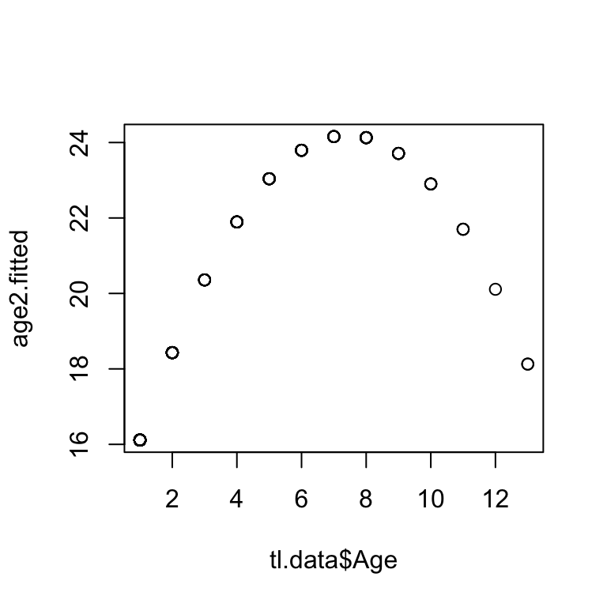

```r
age2.fitted <- predict(m.bm.age.2)
plot(age2.fitted ~ tl.data$Age)
```

However, what this is has done is create a new plot, rather than add the fitted curve to the scatter plot. To achieve the latter, we use `lines()` instead of `plot()`:

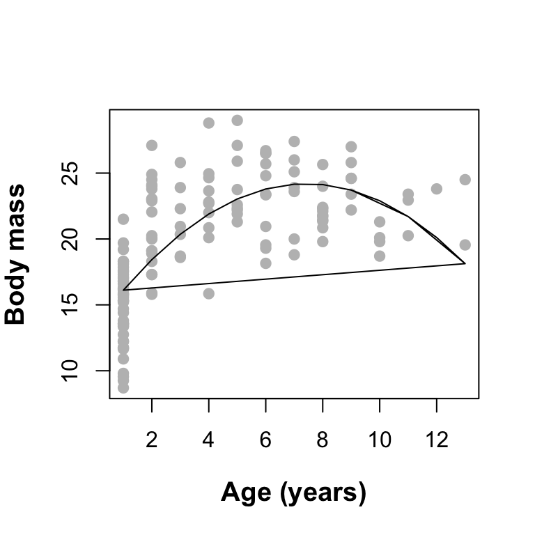

```r
plot(BodyMass ~ Age, data=tl.data, cex.lab=1.2, col="grey", font.lab=2, pch=19,
     xlab="Age (years)", ylab="Body mass")
lines(age2.fitted ~ tl.data$Age)
```

We are getting there, but it has connected the first and the last point. This is a common problem when plotting a line through fitted values: It simply connects one point to the next. It is therefore important to sort the $x$ variable (in this case `Age`) and the $y$ variable (the fitted values for `BodyMass`) by the $x$ variable. We can do this using the `sort()` and `order()` functions:

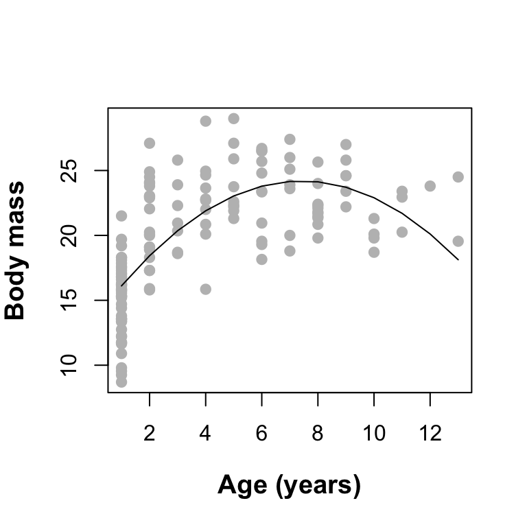

```r
plot(BodyMass ~ Age, data=tl.data, cex.lab=1.2, col="grey", font.lab=2, pch=19,
     xlab="Age (years)", ylab="Body mass")
lines(age2.fitted[order(tl.data$Age)] ~ sort(tl.data$Age))
```

Instead of fitting `Age` and `Age^2` as continuous variables (*i.e.* covariates), we can also fit `Age` as a categorical variable with 13 levels. Although this will result in the estimation of 12 rather than 2 parameters, it does not force the relationship with age to be a 2<sup>nd</sup>-order polynomial (*i.e.* a quadratic relationship). On the other hand, while it will tell us whether body mass varies among age classes, it does not tell us how body mass increases and/or decreases with age.

```r
m.bm.age.factor <- lm(BodyMass ~ as.factor(Age), data = tl.data)
summary(m.bm.age.factor)
```

```
Call:
lm(formula = BodyMass ~ as.factor(Age), data = tl.data)

Residuals:
   Min     1Q Median     3Q    Max
-6.785 -1.866  0.165  1.987  6.495

Coefficients:
                 Estimate Std. Error t value Pr(>|t|)
(Intercept)       15.0053     0.4131  36.326  < 2e-16 ***
as.factor(Age)2    6.0161     0.7433   8.094 4.20e-13 ***
as.factor(Age)3    6.5090     1.1473   5.673 9.12e-08 ***
as.factor(Age)4    7.6297     0.9862   7.736 2.86e-12 ***
as.factor(Age)5    9.0058     1.0304   8.740 1.23e-14 ***
as.factor(Age)6    8.1674     0.9485   8.611 2.51e-14 ***
as.factor(Age)7    8.5375     1.1473   7.441 1.36e-11 ***
as.factor(Age)8    7.1220     0.9485   7.509 9.56e-12 ***
as.factor(Age)9    9.5947     1.2277   7.815 1.88e-12 ***
as.factor(Age)10   4.9697     1.4750   3.369 0.001000 **
as.factor(Age)11   7.1947     1.6864   4.266 3.87e-05 ***
as.factor(Age)12   8.7947     2.8619   3.073 0.002597 **
as.factor(Age)13   7.0197     2.0446   3.433 0.000808 ***
---
Signif. codes:  0 '***' 0.001 '**' 0.01 '*' 0.05 '.' 0.1 ' ' 1

Residual standard error: 2.832 on 126 degrees of freedom
Multiple R-squared:  0.645, Adjusted R-squared:  0.6111
F-statistic: 19.07 on 12 and 126 DF,  p-value: < 2.2e-16
```

```r
anova(m.bm.age.factor)
```

```
Analysis of Variance Table

Response: BodyMass
                Df Sum Sq Mean Sq F value    Pr(>F)
as.factor(Age)  12 1835.5  152.96  19.073 < 2.2e-16 ***
Residuals      126 1010.5    8.02
---
Signif. codes:  0 '***' 0.001 '**' 0.01 '*' 0.05 '.' 0.1 ' ' 1
```

Based on this, we report in our paper: There is a significant effect of age on body mass ($F_{12,126}$=19.07, P < 0.001).

> **EXERCISE 3.7 (HARD)**  
> Looking at the plot, the main difference appears to be between individuals of age 1 and those that are older than 1. Test whether this is indeed the case.

## Differences in body mass between populations

So far we have analysed data for both populations together. However, according to the authors, previous research has shown that both populations experience marked environmental differences. It would therefore be interesting to test if there is a difference in mean `BodyMass` between both populations. To this end, we again fit a linear model, but this time with `Pop` as a categorical predictor:

```r
m.bm.pop <- lm(BodyMass ~ Population, data=tl.data)
summary(m.bm.pop)
```

```
Call:
lm(formula = BodyMass ~ Population, data = tl.data)

Residuals:
   Min     1Q Median     3Q    Max
-9.903 -3.929  1.197  3.446  7.945

Coefficients:
             Estimate Std. Error t value Pr(>|t|)
(Intercept)   18.6030     0.5401   34.44  < 2e-16 ***
PopulationTF   2.4518     0.7453    3.29  0.00128 **
---
Signif. codes:  0 '***' 0.001 '**' 0.01 '*' 0.05 '.' 0.1 ' ' 1

Residual standard error: 4.388 on 137 degrees of freedom
Multiple R-squared:  0.07321,   Adjusted R-squared:  0.06645
F-statistic: 10.82 on 1 and 137 DF,  p-value: 0.001275
```

```r
anova(m.bm.pop)
```

```
Analysis of Variance Table

Response: BodyMass
            Df  Sum Sq Mean Sq F value   Pr(>F)
Population   1  208.36 208.358  10.822 0.001275 **
Residuals  137 2637.64  19.253
---
Signif. codes:  0 '***' 0.001 '**' 0.01 '*' 0.05 '.' 0.1 ' ' 1
```

> **EXERCISE 3.8**  
> What do you conclude on the basis of this model? What is the mean body mass for each population?

## Simultaneously testing for the effects of age, population and sex

It is not unlikely that body mass does not only differ between populations, but also between males and females, and between the different age classes. To test this, and to estimate the effect of each of these variables on body mass, we can fit a linear model that includes all of these variables as predictors:

```r
m.bm.full <- lm(BodyMass ~ Age + I(Age^2) + Population + Sex, data=tl.data)
summary(m.bm.full)
```

```
Call:
lm(formula = BodyMass ~ Age + I(Age^2) + Population + Sex, data = tl.data)

Residuals:
    Min      1Q  Median      3Q     Max
-6.8140 -1.4168 -0.1849  1.5752  6.7144

Coefficients:
             Estimate Std. Error t value Pr(>|t|)
(Intercept)  10.69917    0.64986  16.464  < 2e-16 ***
Age           3.05265    0.25422  12.008  < 2e-16 ***
I(Age^2)     -0.20146    0.02269  -8.878 3.87e-15 ***
PopulationTF  3.08622    0.45982   6.712 4.96e-10 ***
SexM          1.30071    0.46942   2.771  0.00639 **
---
Signif. codes:  0 '***' 0.001 '**' 0.01 '*' 0.05 '.' 0.1 ' ' 1

Residual standard error: 2.686 on 134 degrees of freedom
Multiple R-squared:  0.6603,    Adjusted R-squared:  0.6501
F-statistic: 65.11 on 4 and 134 DF,  p-value: < 2.2e-16
```

> **EXERCISE 3.9**  
> Based on this output, what is the predicted body mass of a 5-year old male that lives in the TF population?

We could use `anova()`:

```r
anova(m.bm.full)
```

```
Analysis of Variance Table

Response: BodyMass
            Df Sum Sq Mean Sq  F value    Pr(>F)
Age          1 938.89  938.89 130.1274 < 2.2e-16 ***
I(Age^2)     1 539.98  539.98  74.8398 1.391e-14 ***
Population   1 344.89  344.89  47.8002 1.747e-10 ***
Sex          1  55.40   55.40   7.6779  0.006385 **
Residuals  134 966.84    7.22
---
Signif. codes:  0 '***' 0.001 '**' 0.01 '*' 0.05 '.' 0.1 ' ' 1
```

Although the p-value for the `Sex` effect is identical to that obtained previously, this is not true for the others. This is because only the `Sex` effect is estimated while accounting for all the other effects.

> **EXERCISE 3.10**  
> Change the order of the effects in `m.bm.full` and see how this impacts the p-values provided by `summary()` and `anova()`.

Instead, to test whether the inclusion of `Population` significantly improves the fit of the model, we fit a model without `Population`:

```r
m.bm.no.pop <- lm(BodyMass ~ Age + I(Age^2) + Sex, data=tl.data)
```

and compare this to `m.bm.full` using `anova()`:

```r
anova(m.bm.no.pop, m.bm.full)
```

```
Analysis of Variance Table

Model 1: BodyMass ~ Age + I(Age^2) + Sex
Model 2: BodyMass ~ Age + I(Age^2) + Population + Sex
  Res.Df     RSS Df Sum of Sq      F    Pr(>F)
1    135 1291.87
2    134  966.84  1    325.04 45.049 4.956e-10 ***
---
Signif. codes:  0 '***' 0.001 '**' 0.01 '*' 0.05 '.' 0.1 ' ' 1
```

This has provided us with the significance of the difference in body mass between both populations, while accounting for all other effects in the model. Note that the p-value is identical to that obtained by the t-test reported by `summary()`.

You now have all the information you need to report the population effect in a publication. For example, you could write something like: After accounting for the effects of age and sex, there was a statistically significant difference in body mass between the two study population, with individuals in the TF population being 3.09 ± 0.46 kg heavier than individuals in the CH population ($F_{1,134}$=45.1, P < 0.001).

> **EXERCISE 3.11 (HARD)**  
> Our full model (`m.bm.full`) did not include any interaction terms. Fit a model that includes all 2-way interactions and use model simplification to arrive at the Minimal Adequate Model (MAM).

# The effect of age on telomere length, revisited

In section 3, we concluded that there was no evidence for an effect of age on telomere length. However, in section 4 we found strong evidence for differences between both populations in terms of body mass. It might therefore be worth looking at this relationship in both populations separately.

We can start with two separate regressions:

```r
summary(lm(RTL ~ Age, data=tl.data[tl.data$Pop=="CH",]))
```

```
Call:
lm(formula = RTL ~ Age, data = tl.data[tl.data$Pop == "CH", ])

Residuals:
     Min       1Q   Median       3Q      Max
-0.30941 -0.14546 -0.02056  0.16119  0.49725

Coefficients:
             Estimate Std. Error t value Pr(>|t|)
(Intercept)  1.072115   0.036404  29.451   <2e-16 ***
Age         -0.010754   0.006718  -1.601    0.114
---
Signif. codes:  0 '***' 0.001 '**' 0.01 '*' 0.05 '.' 0.1 ' ' 1

Residual standard error: 0.1776 on 64 degrees of freedom
Multiple R-squared:  0.0385,    Adjusted R-squared:  0.02347
F-statistic: 2.562 on 1 and 64 DF,  p-value: 0.1144
```

```r
summary(lm(RTL ~ Age, data=tl.data[tl.data$Pop=="TF",]))
```

```
Call:
lm(formula = RTL ~ Age, data = tl.data[tl.data$Pop == "TF", ])

Residuals:
     Min       1Q   Median       3Q      Max
-0.33291 -0.10355 -0.01289  0.09540  0.42488

Coefficients:
            Estimate Std. Error t value Pr(>|t|)
(Intercept) 1.064880   0.029810  35.722   <2e-16 ***
Age         0.011729   0.005978   1.962   0.0537 .
---
Signif. codes:  0 '***' 0.001 '**' 0.01 '*' 0.05 '.' 0.1 ' ' 1

Residual standard error: 0.1652 on 71 degrees of freedom
Multiple R-squared:  0.05142,   Adjusted R-squared:  0.03806
F-statistic: 3.849 on 1 and 71 DF,  p-value: 0.0537
```

This is looking promising: Although in neither of the two populations the effect is significantly different from zero (although it is close in the TF population), the effects are going in opposite directions.

However, to formally test whether the effect of age differs between the two populations, we need to test whether the interaction between `Age` and `Population` is significant:

```r
m.age.pop.int <- lm(RTL ~ Age + Population + Age:Population, data=tl.data)
summary(m.age.pop.int)
```

```
Call:
lm(formula = RTL ~ Age + Population + Age:Population, data = tl.data)

Residuals:
     Min       1Q   Median       3Q      Max
-0.33291 -0.12761 -0.01632  0.11736  0.49725

Coefficients:
                  Estimate Std. Error t value Pr(>|t|)
(Intercept)       1.072115   0.035096  30.548   <2e-16 ***
Age              -0.010754   0.006477  -1.660   0.0992 .
PopulationTF     -0.007235   0.046751  -0.155   0.8772
Age:PopulationTF  0.022482   0.008962   2.509   0.0133 *
---
Signif. codes:  0 '***' 0.001 '**' 0.01 '*' 0.05 '.' 0.1 ' ' 1

Residual standard error: 0.1712 on 135 degrees of freedom
Multiple R-squared:  0.09796,   Adjusted R-squared:  0.07792
F-statistic: 4.887 on 3 and 135 DF,  p-value: 0.002947
```

Note that we could also have specified the model like this:

```r
m.age.pop.int <- lm(RTL ~ Age*Population, data=tl.data)
```

> **EXERCISE 3.12**  
> How do the parameter estimates from this model relate to those provided by the two separate regressions?

To test whether the interaction term is significant, we compare this model to a model that only includes the main effects of `Age` and `Population`:

```r
m.age.pop <- lm(RTL ~ Age + Population, data=tl.data)
anova(m.age.pop, m.age.pop.int)
```

```
Analysis of Variance Table

Model 1: RTL ~ Age + Population
Model 2: RTL ~ Age * Population
  Res.Df    RSS Df Sum of Sq      F Pr(>F)
1    136 4.1410
2    135 3.9566  1   0.18445 6.2936 0.0133 *
---
Signif. codes:  0 '***' 0.001 '**' 0.01 '*' 0.05 '.' 0.1 ' ' 1
```

> **EXERCISE 3.13**  
> Does this result match the result reported by the authors?

To conclude, we would like to plot the this result. To do this, we first plot the results for one population, and then use `points()` to add the results for the other population in a different colour. Finally, we add use `legend()` to add a legend to the plot:

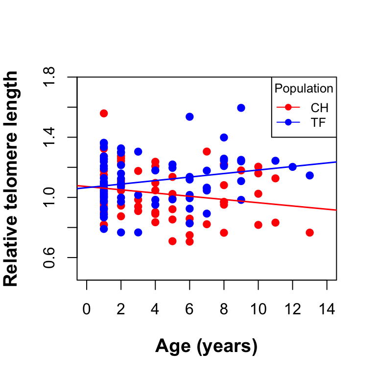

```r
plot(RTL ~ Age, data=tl.data[tl.data$Pop=="CH",], cex.lab=1.2, xlim=c(0,14),
     ylim=c(0.5, 1.75), pch=19, col="red", font.lab=2,
     xlab="Age (years)", ylab="Relative telomere length")

points(RTL ~ Age, data=tl.data[tl.data$Pop=="TF",], pch=19, col="blue")
abline(lm(RTL ~ Age, data=tl.data[tl.data$Pop=="CH",]), col="red", lwd=1.5)
abline(lm(RTL ~ Age, data=tl.data[tl.data$Pop=="TF",]), col="blue", lwd=1.5)

legend(x="topright", legend=c("CH", "TF"), pch=19, lty = 1,
       col=c("red", "blue"), title="Population", cex=0.8)
```

> **TIP**  
> `R` determines the optimal limits of the axes on the basis of the range of the data used when generating the first plot, and some of the data points added later using `points()` may fall outside of this range. You can avoid this my determining the range of the *complete* data set (for example using `min()` and `max()`), and use this to set `xlim` and `ylim` (as we did above). Alternatively, you could first plot all the data, but use `pch=NA` (*i.e.* no symbols), and then add both series of data points.

> **EXERCISE 3.14**  
> The authors conclude that habitat quality shapes telomere dynamics. Do you agree with this conclusion?